# Tarea3_Alejandro_Barrantes

Alejandro Barrantes Castro

2023-03-28

# Ejercicio #1

```r
setwd("~/ALEJANDRO/1er Ciclo 2023/Mineria de Datos/Tarea 3/Datos de la Presentación y para la Tarea")
datos <- read.table('SpotifyTop2018_40_V2.csv',header=TRUE, sep=',',dec='.')
```

### a) Calcule el resumen numerico, interprete los resultados para dos variables

```r
summary(datos)
```

```
##   danceability        energy          loudness       speechiness
##  Min.   :0.2580   Min.   :0.3910   Min.   :-9.211   Min.   :0.02320
##  1st Qu.:0.6805   1st Qu.:0.5643   1st Qu.:-7.077   1st Qu.:0.04955
##  Median :0.7500   Median :0.6590   Median :-5.930   Median :0.10550
##  Mean   :0.7192   Mean   :0.6619   Mean   :-5.846   Mean   :0.12129
##  3rd Qu.:0.8175   3rd Qu.:0.7725   3rd Qu.:-4.624   3rd Qu.:0.14450
##  Max.   :0.9220   Max.   :0.9090   Max.   :-3.093   Max.   :0.51600
##   acousticness      instrumentalness       liveness          valence
##  Min.   :0.000282   Min.   :0.000e+00   Min.   :0.02150   Min.   :0.0967
##  1st Qu.:0.030800   1st Qu.:0.000e+00   1st Qu.:0.09527   1st Qu.:0.2875
##  Median :0.121500   Median :3.220e-06   Median :0.11200   Median :0.4375
##  Mean   :0.184621   Mean   :3.695e-03   Mean   :0.17713   Mean   :0.4679
##  3rd Qu.:0.227500   3rd Qu.:4.325e-05   3rd Qu.:0.29475   3rd Qu.:0.6332
##  Max.   :0.847000   Max.   :1.340e-01   Max.   :0.55200   Max.   :0.9310
##      tempo         duration_ms     time_signature
##  Min.   : 77.17   Min.   : 95467   Min.   :3.00
##  1st Qu.: 95.04   1st Qu.:189856   1st Qu.:4.00
##  Median :122.53   Median :212905   Median :4.00
##  Mean   :122.11   Mean   :205646   Mean   :3.95
##  3rd Qu.:140.59   3rd Qu.:226983   3rd Qu.:4.00
##  Max.   :191.70   Max.   :268867   Max.   :4.00
```

- Variables:
  - energy: En promedio las canciones son bastantes intensas.
  - Danceability: En promedio son bastante bailables, una buena parte son bailables.

### b) Realice un grafico de dispersion e interprete dos similitudes en el grafico

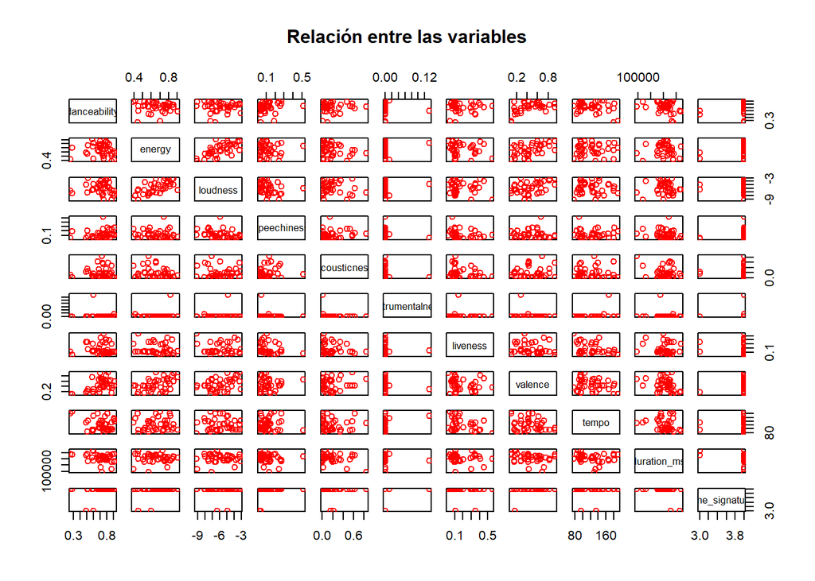

```r
plot(datos,main = "Relación entre las variables",
     pch = 21, # Tipo de la forma
     col = "red",# color del los formas del gráfico
     cex.main = .95)
```

### c) Para dos variables identifique los datos atıpicos, si los hay.

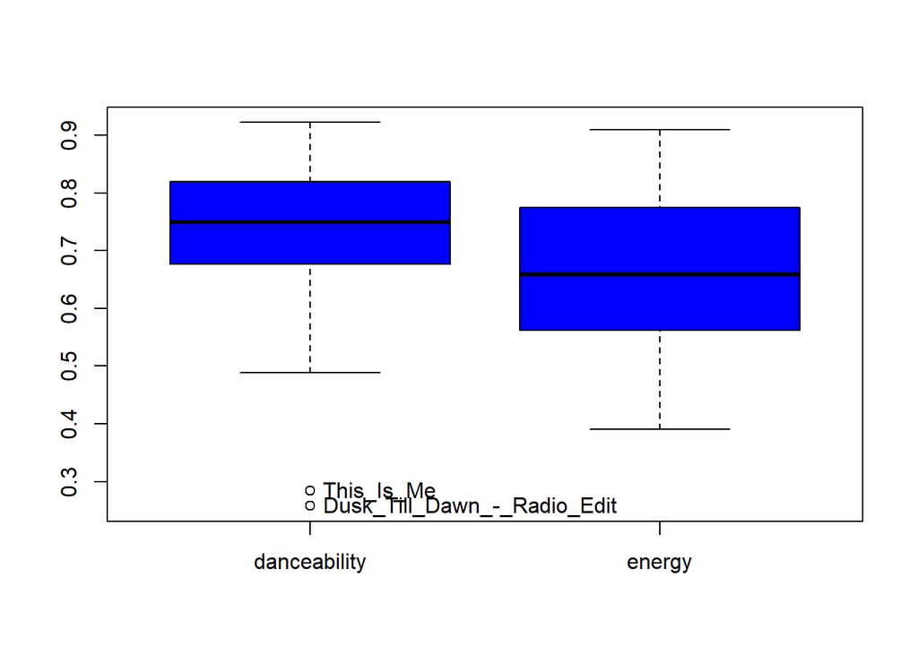

```r
atipicos<-Boxplot(datos[,c(1,2)],data=datos[,c(1,2)],id.method="y",col="Blue")
```

```r
atipicos
```

```
## [1] "Dusk_Till_Dawn_-_Radio_Edit" "This_Is_Me"
```

### d) Calcule la matriz de correlaciones, incluya alguna de las imagenes que ofrece R e interprete dos de las correlaciones. Debe ser una interpretacion dirigida a una persona que no sabe nada de estadıstica.

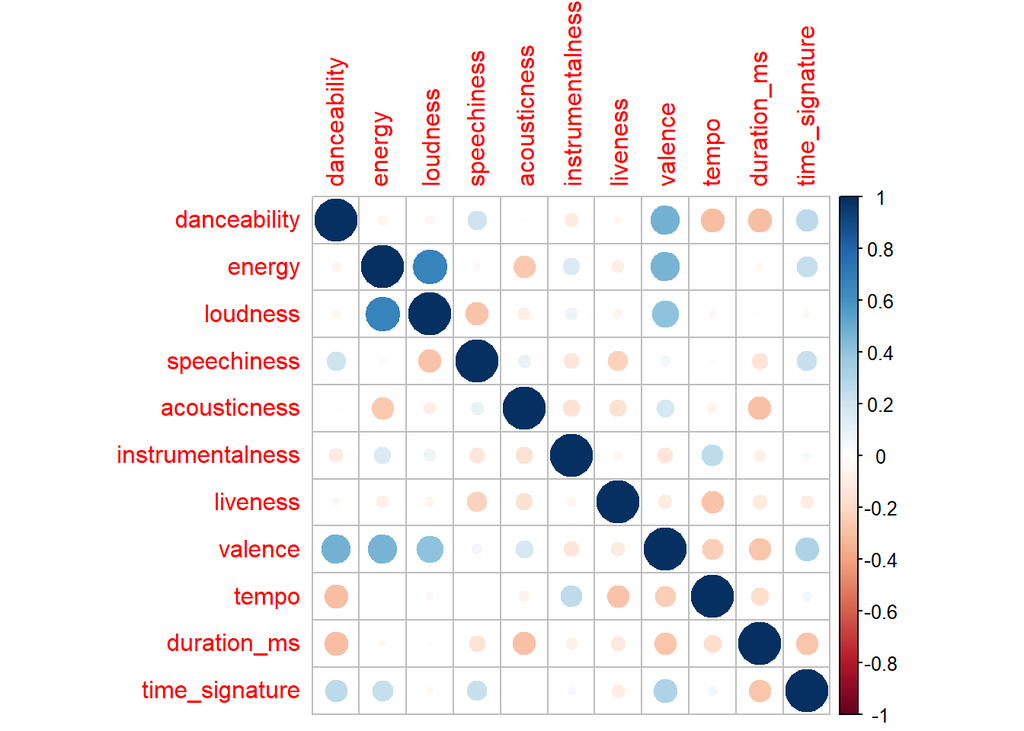

```r
matriz.correlacion<-cor(datos)
corrplot(matriz.correlacion)
```

- Correlaciones:
  - Valence-Danceability: Como se puede observar en el grafico, en el eje de valence y danceability se encuentra un circulo de buen tamannio, lo que significa que estas 2 variables tienen buena correlacion, lo que tiene sentido, porque si una cancion tiene bastante positividad, es posible que tambien sea bastante bailable.Esto se conoce como una correlacion fuerte y positiva.
  - Energy-Duration: Como vemos en el eje donde se cruzan energy y duration, no existe ningun circulo, por lo tanto significa poca correlacion, se debe a que la energia expresada en una cancion no tiene nada que ver con la duracion de la misma

### e) Efectue un ACP y de una interpretacion siguiendo los siguientes pasos:

```r
modelo <- prcomp(datos,scale. = TRUE,center = TRUE)
res<-PCA(datos, scale.unit=TRUE, ncp=5, graph = FALSE)
mi.tema <- theme_grey() + theme(panel.border = element_rect(fill = NA,color = "white"), plot.title = element_text(hjust = 0.5))
```

#### En el cırculo de correlacion determine la correlacion entre las variables.

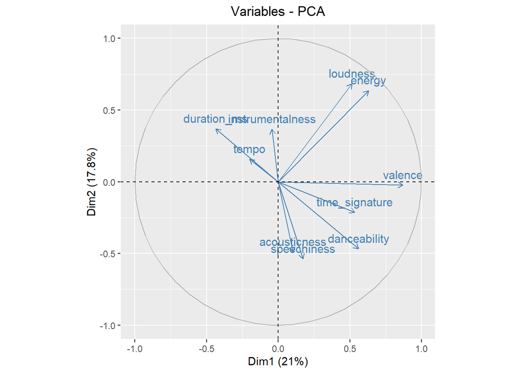

```r
fviz_pca_var(res,col.var="steelblue",ggtheme = mi.tema,select.var = list(cos2 = 0.05))
```

- Como se puede observar en el grafico, tenemos 3 clusteres vistosos, los cuales son:
  - Duration, instrumentalness, tempo.
  - loudness, energy.
  - valence, time_signature, danceability, acousticness, speechiness.

#### Explique la formacion de los clusteres basado en la sobre-posicion del cırculo y el plano

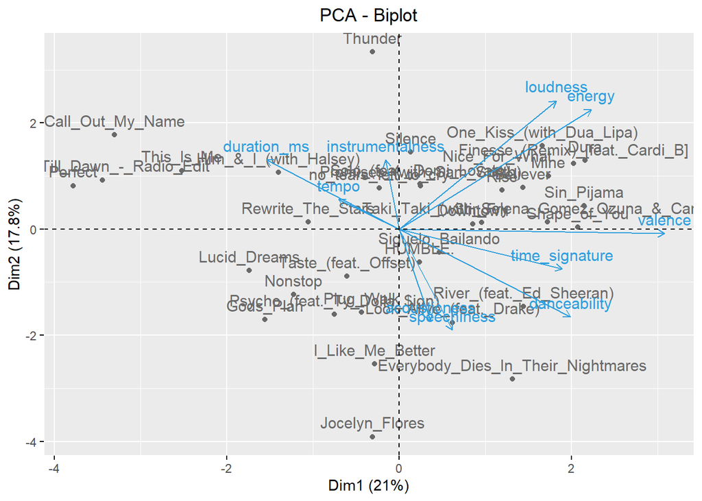

```r
fviz_pca_biplot(res,col.var = "#2E9FDF",col.ind = "#696969",ggtheme = mi.tema, select.ind = list(cos2 = 0.05),select.var = list(cos2 = 0.05))
```

Imagen con clusteres

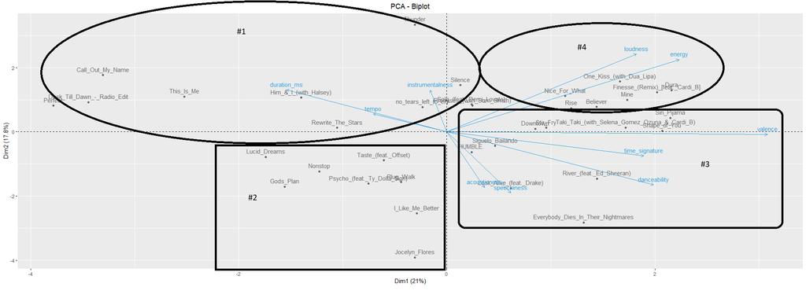

Imagen donde se aprecian los clusteres!

- Gracias al grafico con sobreposicion se aprecia lo siguiente:
  - Tenemos a simple vista 4 clusteres
  - Los individuos del cluster #1 se relacionan con las variables duration_ms, tempo y instrumentalness.
  - Los individuos del cluster #2 no tienen mucha relacion con ninguna de las variables.
  - Los individuos del cluster #3 tienen relacion con las variables acousticness, speechiness, time_signature, danceability, valence
  - Los individuos del cluster #4 tienen relacion con las variables loudness y energy

#### En el plano de los componentes 1 y 3 interprete las canciones In My Feelings, In My Mind, Havana, Candy Paint y HUMBLE, que son mal representadas en los componentes 1 y 2.

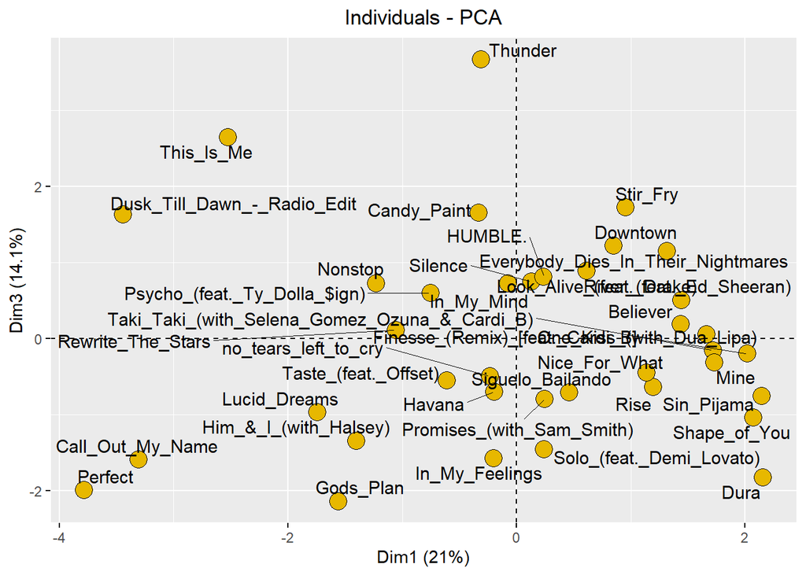

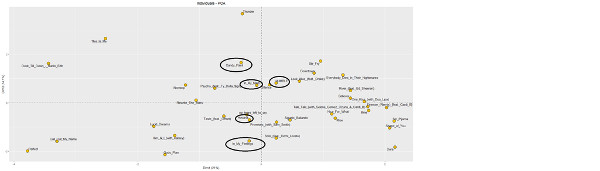

```r
fviz_pca_ind(res, pointsize = 5, pointshape = 21, fill = "#E7B800", repel = TRUE, select.ind = list(cos2 = 0.05),ggtheme = mi.tema, axes=c(1, 3))
```

- Segun la imagen, se puede apreciar lo siguiente:
  - “In my Feelings” esta apartada de todas las variables, es decir, tiene bajos numeros en todas las variables.
  - “In my mind” y “Candy Paint” tiende hacia instrumentalness, es decir, obtuvieron altos numeros en la variable instrumentalness.
  - Con “Havana” sucede lo mismo que con “In my feelings”
  - “Humble” tiende hacia acousticness y speechiness, es decir, obtuvo buenos numeros en estas dos variables.

# Ejercicio #2

```r
setwd("~/ALEJANDRO/1er Ciclo 2023/Mineria de Datos/Tarea 3/Datos de la Presentación y para la Tarea")
datos <- read.table('TablaAffairs.csv',header=TRUE, sep=';',dec='.')
mi.tema <- theme_grey() + theme(panel.border = element_rect(fill = NA,color = "white"), plot.title = element_text(hjust = 0.5))
```

### a) Calcule el resumen numerico, interprete los resultados para una variable

```r
datos2 <- datos[, sapply(datos, is.numeric)]
summary(datos2)
```

```
##        X        TiempoInfiel         Edad        AnnosCasado
##  Min.   :  1   Min.   : 0.000   Min.   :17.50   Min.   : 0.125
##  1st Qu.:151   1st Qu.: 0.000   1st Qu.:27.00   1st Qu.: 4.000
##  Median :301   Median : 0.000   Median :32.00   Median : 7.000
##  Mean   :301   Mean   : 1.456   Mean   :32.49   Mean   : 8.178
##  3rd Qu.:451   3rd Qu.: 0.000   3rd Qu.:37.00   3rd Qu.:15.000
##  Max.   :601   Max.   :12.000   Max.   :57.00   Max.   :15.000
##    Religioso       Educacion       Ocupacion
##  Min.   :0.510   Min.   : 8.89   Min.   :1.000
##  1st Qu.:2.110   1st Qu.:14.27   1st Qu.:3.000
##  Median :3.200   Median :16.39   Median :5.000
##  Mean   :3.128   Mean   :16.19   Mean   :4.195
##  3rd Qu.:4.140   3rd Qu.:17.86   3rd Qu.:6.000
##  Max.   :5.490   Max.   :20.50   Max.   :7.000
```

#### Gracias al resumen que obtuvimos, podemos ver que en la variable Edad, se entrevistaron a personas desde los 17 annios hsta los 57, una buena poblacion. Y que hubieron bastantes personas rondando los 30 annios de edad.

### b) Calcule la matriz de correlaciones, incluya alguna de las imagenes que ofrece R e interprete dos de las correlaciones.Debe ser una interpretacion dirigida a una persona que no sabe nada de estadıstica.

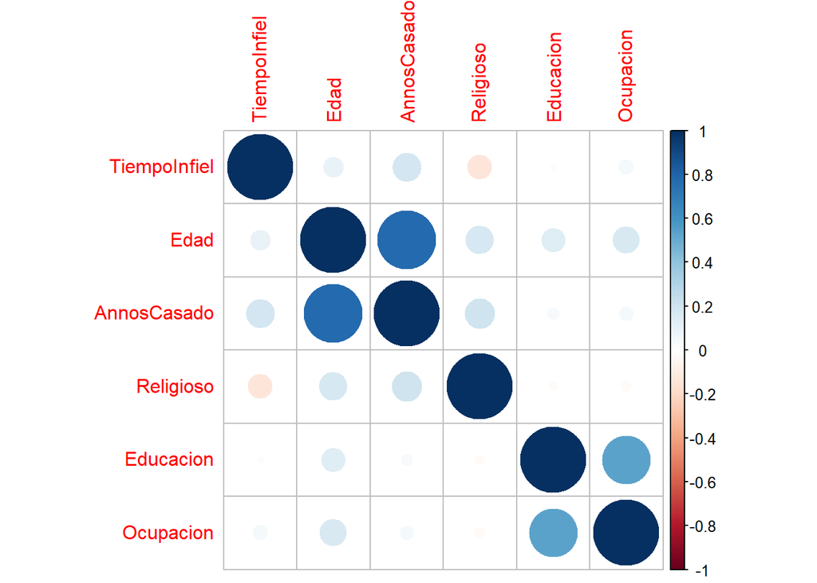

```r
matriz.correlacion<-cor(datos2[,-c(1)])
corrplot(matriz.correlacion)
```

- Correlaciones:
  - Edad-AnnosCasado: Como se puede observar en el grafico, en el eje de Edad y AnnosCasado se encuentra un circulo de buen tamannio, lo que significa que estas 2 variables tienen buena correlacion, lo que tiene sentido, porque si una persona tiene bastante edad, es posible que tambien tenga bastantes mas annos de casado.Esto se conoce como una correlacion fuerte y positiva.
  - Educacion-TiempoInfiel: Como vemos en el eje donde se cruzan Educacion y TiempoInfiel, no existe ningun circulo, por lo tanto significa poca correlacion, ya que la educacion de una persona no tiene nada que ver con el tiempo que ha sido infiel.

### c) Usando solo las variables numericas efectue un ACP y de una interpretacion siguiendo lossiguientes pasos: 1) Elimine de los graficos individuos y variables con menos del 5 % de calidad de representacion,

```r
res<-PCA(datos2[,-c(1)], scale.unit=TRUE, ncp=5, graph = FALSE)
```

#### 2) en el plano principal encuentre 4 clusteres,

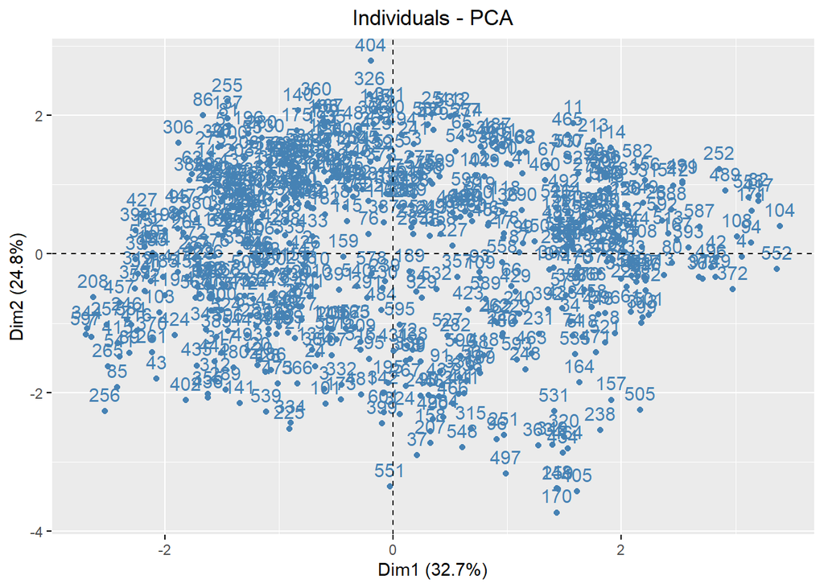

[figure not shown]

```r
fviz_pca_ind(res,col.ind ="steelblue",ggtheme = mi.tema,select.ind = list(cos2 = 0.05))
```

#### 3) en el cırculo de correlacion determine la correlacion entre las variables

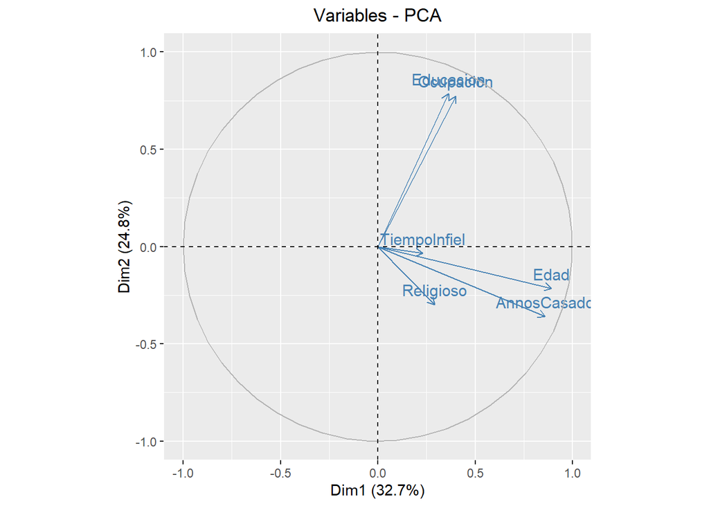

```r
fviz_pca_var(res,col.var="steelblue",ggtheme = mi.tema,select.var = list(cos2 = 0.05))
```

#### 4) explique la formacion de los clusteres basado en la sobre-posicion del cırculo y el plano.

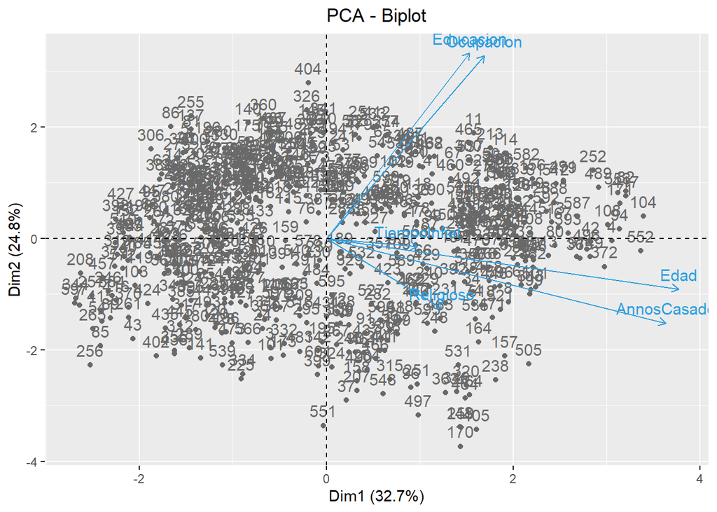

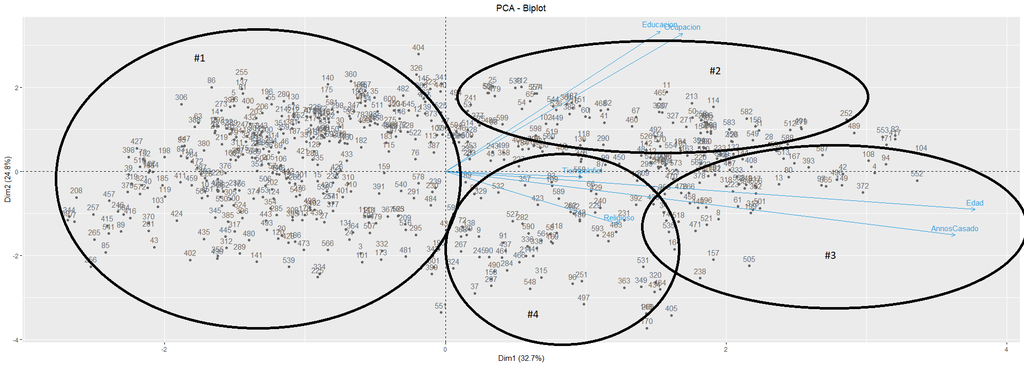

4 clusteres!

```r
fviz_pca_biplot(res,col.var = "#2E9FDF",col.ind = "#696969",ggtheme = mi.tema, select.ind = list(cos2 = 0.05),select.var = list(cos2 = 0.05))
```

### d) Ahora convierta las variables Genero e Hijos en Codigo Disyuntivo Completo y repita el ACP ¿Se gana interpretabilidad al convetir Genero e Hijos en Codigo Disyuntivo Completo?

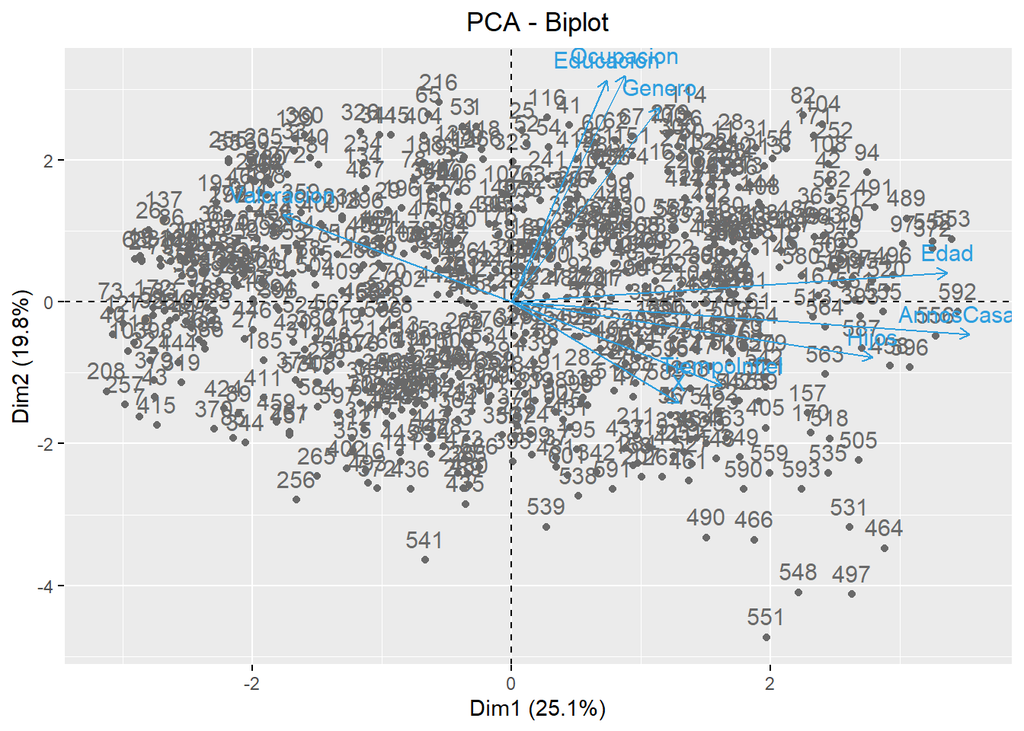

```r
datos <- datos %>%dplyr::mutate(Genero = dplyr::recode(Genero,"male" = 1,"female" = 0))

datos <- datos %>% dplyr::mutate(Hijos = dplyr::recode(Hijos,"yes" = 1, "no" = 0))

datos <- datos %>% dplyr::mutate(Valoracion = dplyr::recode(Valoracion,
                                                            "muy infeliz" = 0,
                                                            "infeliz" = 1,
                                                            "neural"=2,
                                                            "feliz"=3,
                                                            "muy feliz"=4))

resDis<-PCA(datos, scale.unit=TRUE, ncp=5, graph = FALSE)
fviz_pca_biplot(resDis,col.var = "#2E9FDF",col.ind = "#696969",ggtheme = mi.tema, select.var = list(cos2 = 0.05), axes=c(1, 2))
```

#### Como tal, una mejor interpretabilidad no se genera, ya que lo cambia es en realidad demasiado poco, sin embargo se aprecian pequennos cambios, como la correlacion entre el genero-educacion-ocupacion y la correlacion entre hijos-religioso-anniosCasado.

# EJERCICIO 3

## PARTE A

```r
setwd("~/ALEJANDRO/1er Ciclo 2023/Mineria de Datos/Tarea 3/Datos de la Presentación y para la Tarea")
datos <- read.table('SAheart.csv',header=TRUE, sep=';',dec='.')
mi.tema <- theme_grey() + theme(panel.border = element_rect(fill = NA,color = "white"), plot.title = element_text(hjust = 0.5))
```

### a) Efectue un ACP usando solo las variables numericas y de una interpretacion siguiendo los siguientes pasos (para todos los ejercicios elimine de los graficos individuos y variables con menos del 5 % de calidad de representacion):

```r
datos2 <- datos[, sapply(datos, is.numeric)]
summary(datos2)
```

```
##       sbp           tobacco             ldl           adiposity
##  Min.   :101.0   Min.   : 0.0000   Min.   : 0.980   Min.   : 6.74
##  1st Qu.:124.0   1st Qu.: 0.0525   1st Qu.: 3.283   1st Qu.:19.77
##  Median :134.0   Median : 2.0000   Median : 4.340   Median :26.11
##  Mean   :138.3   Mean   : 3.6356   Mean   : 4.740   Mean   :25.41
##  3rd Qu.:148.0   3rd Qu.: 5.5000   3rd Qu.: 5.790   3rd Qu.:31.23
##  Max.   :218.0   Max.   :31.2000   Max.   :15.330   Max.   :42.49
##      typea         obesity         alcohol            age
##  Min.   :13.0   Min.   :14.70   Min.   :  0.00   Min.   :15.00
##  1st Qu.:47.0   1st Qu.:22.98   1st Qu.:  0.51   1st Qu.:31.00
##  Median :53.0   Median :25.80   Median :  7.51   Median :45.00
##  Mean   :53.1   Mean   :26.04   Mean   : 17.04   Mean   :42.82
##  3rd Qu.:60.0   3rd Qu.:28.50   3rd Qu.: 23.89   3rd Qu.:55.00
##  Max.   :78.0   Max.   :46.58   Max.   :147.19   Max.   :64.00
```

```r
res<-PCA(datos2, scale.unit=TRUE, ncp=5, graph = FALSE)
```

#### En el plano principal encuentre los clusteres.

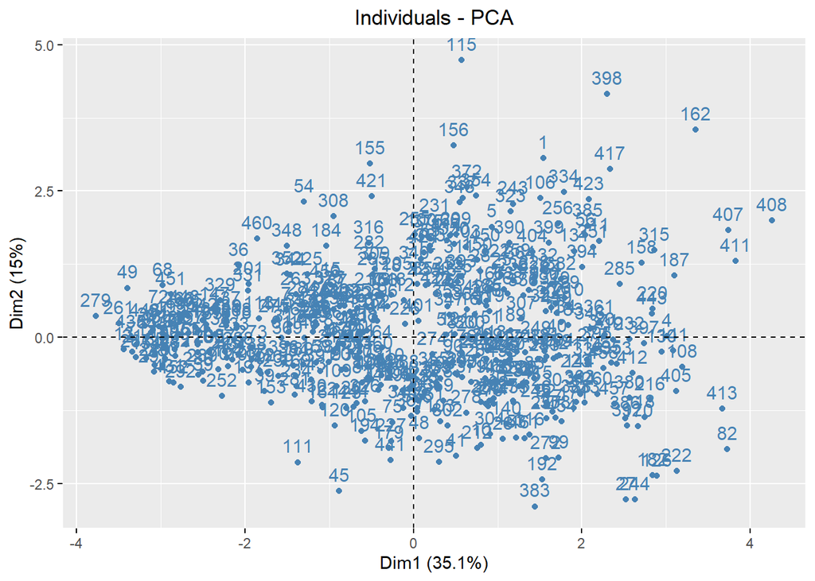

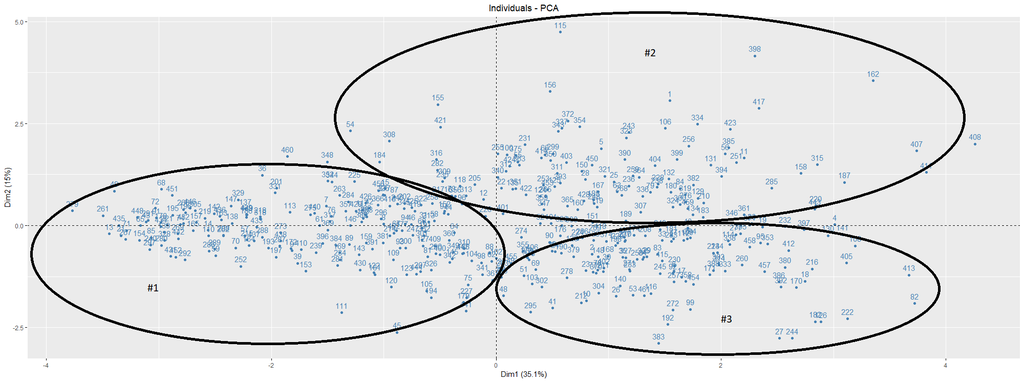

```r
fviz_pca_ind(res,col.ind ="steelblue",ggtheme = mi.tema,select.ind = list(cos2 = 0.05))
```

#### En el cırculo de correlacion determine la correlacion entre las variables.

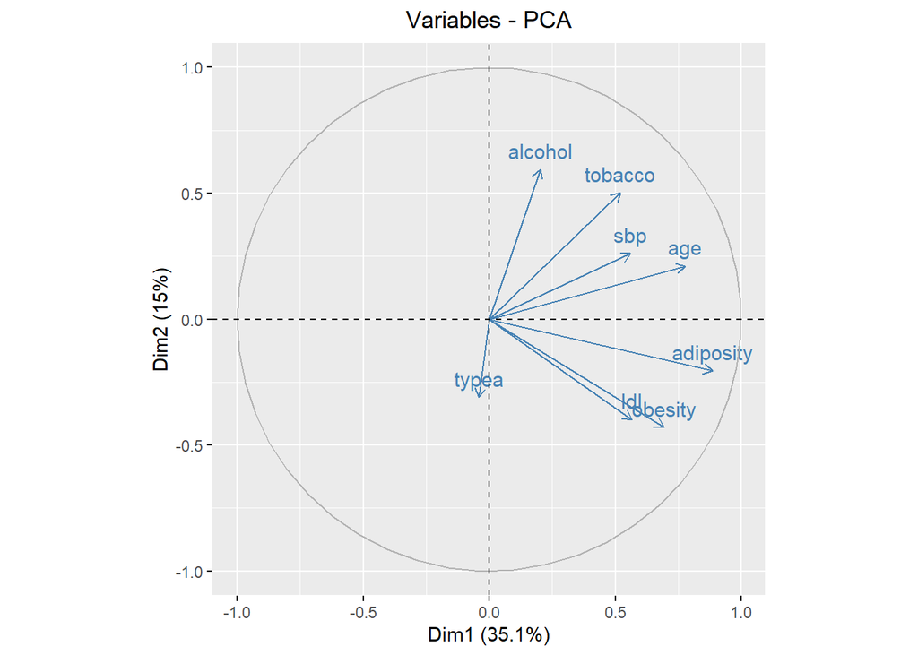

```r
fviz_pca_var(res,col.var="steelblue", select.var = list(cos2 = 0.05),ggtheme = mi.tema, axes=c(1, 2))
```

#### Explique la formacion de los clusteres basado en la sobre-posicion del cırculo y el plano

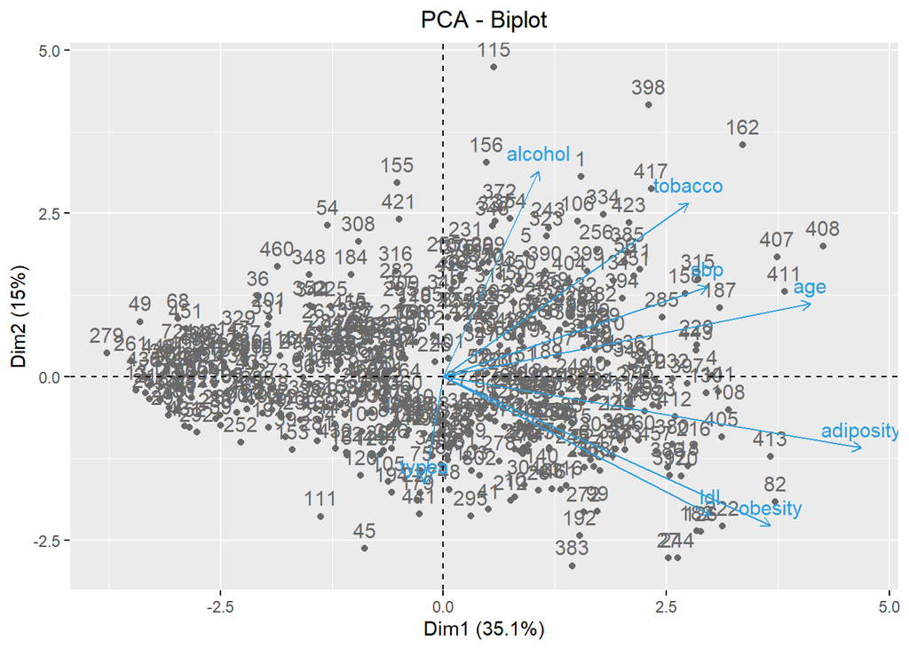

```r
fviz_pca_biplot(res,col.var = "#2E9FDF",col.ind = "#696969",ggtheme = mi.tema, select.ind = list(cos2 = 0.05),select.var = list(cos2 = 0.05))
```

- **Clusteres**:
  - Cluster #1: Son indivduos los cuales no tienen mucha relacion a ninguna de las variables, es decir, los numeros son bajos o directamente no tienen relacion entre si.
  - Cluster #2: Son individuos que tienen numeros altos en las variables alcohol-tobacco-sbp y age, podrian ser individuos con vicios
  - Cluster #3: Son individuos que tienen numeros altos en las variables ldl-adiposity-sbp y obesity, lo que tiene sentido, ya que si una persona sufre de obesidad, tendra una gran adiposidad, que significa acumulacion de grasa en el cuerpo.

## PARTE B

```r
datos <- datos %>%
  dplyr::mutate(famhist = dplyr::recode(famhist,
                                        "Present" = 1,
                                        "Absent" = 0))
str(datos)
```

```
## 'data.frame':    462 obs. of  10 variables:
##  $ sbp      : int  160 144 118 170 134 132 142 114 114 132 ...
##  $ tobacco  : num  12 0.01 0.08 7.5 13.6 6.2 4.05 4.08 0 0 ...
##  $ ldl      : num  5.73 4.41 3.48 6.41 3.5 6.47 3.38 4.59 3.83 5.8 ...
##  $ adiposity: num  23.1 28.6 32.3 38 27.8 ...
##  $ famhist  : num  1 0 1 1 1 1 0 1 1 1 ...
##  $ typea    : int  49 55 52 51 60 62 59 62 49 69 ...
##  $ obesity  : num  25.3 28.9 29.1 32 26 ...
##  $ alcohol  : num  97.2 2.06 3.81 24.26 57.34 ...
##  $ age      : int  52 63 46 58 49 45 38 58 29 53 ...
##  $ chd      : chr  "Si" "Si" "No" "Si" ...
```

```r
datos <- datos %>%
  dplyr::mutate(chd = dplyr::recode(chd,
                                    "Si" = 1,
                                    "No" = 0))

res<-PCA(datos, scale.unit=TRUE, ncp=5, graph = FALSE)
```

#### En el plano principal encuentre los clusteres.

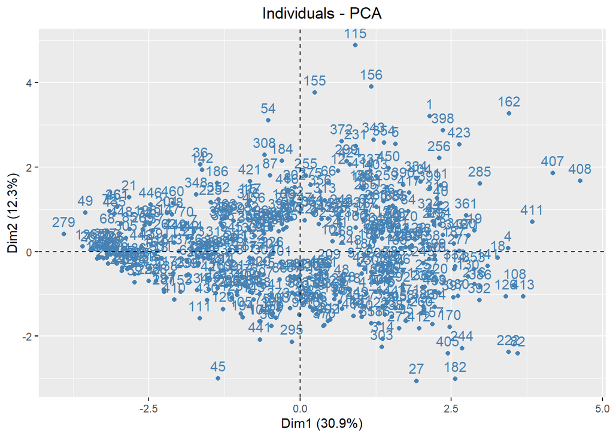

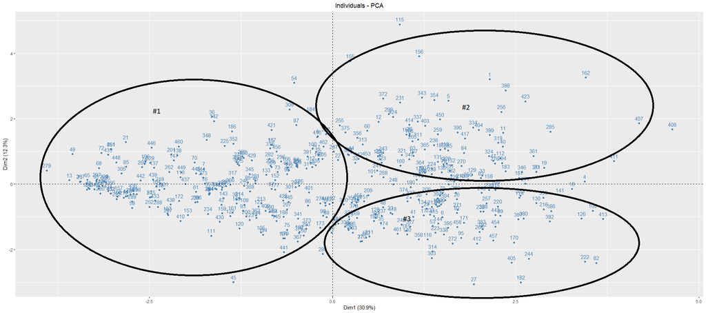

```r
fviz_pca_ind(res,col.ind ="steelblue",ggtheme = mi.tema,select.ind = list(cos2 = 0.05))
```

#### En el cırculo de correlacion determine la correlacion entre las variables.

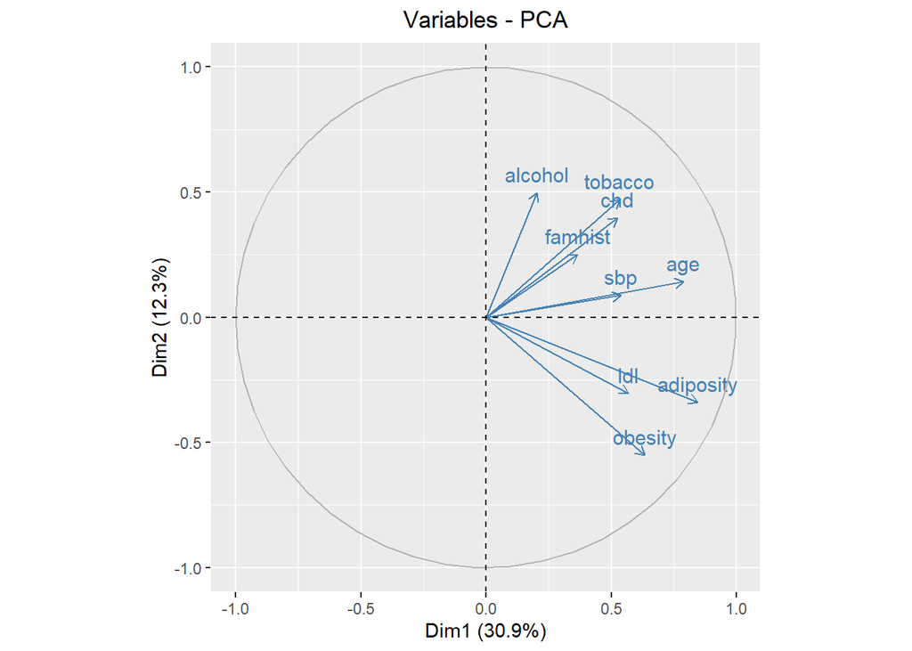

```r
fviz_pca_var(res,col.var="steelblue", select.var = list(cos2 = 0.05),ggtheme = mi.tema, axes=c(1, 2))
```

#### Explique la formacion de los clusteres basado en la sobre-posicion del cırculo y el plano

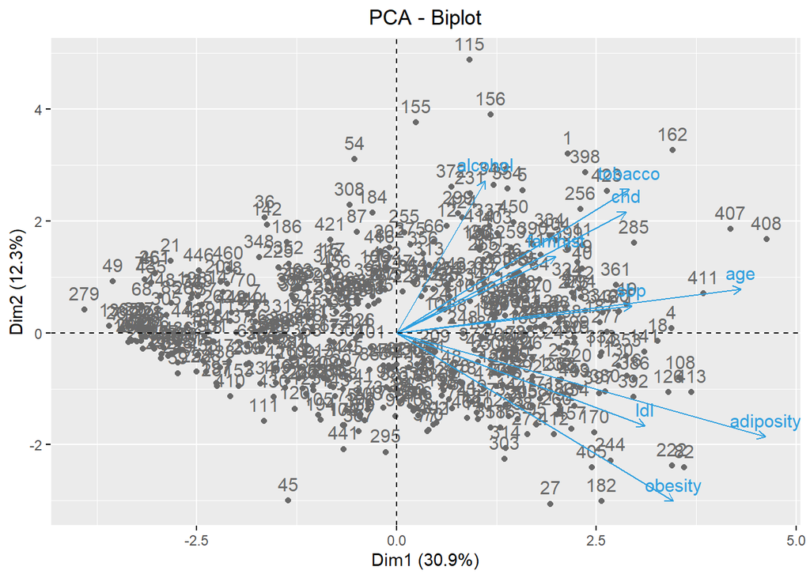

```r
fviz_pca_biplot(res,col.var = "#2E9FDF",col.ind = "#696969",ggtheme = mi.tema, select.ind = list(cos2 = 0.05),select.var = list(cos2 = 0.05))
```

- **Clusteres**:
  - Cluster #1: Son indivduos los cuales no tienen mucha relacion a ninguna de las variables, es decir, los numeros son bajos o directamente no tienen relacion entre si.
  - Cluster #2: Son individuos que tienen numeros altos en las variables alcohol-tobacco-sbp y age, podrian ser individuos con vicios, pero que tambien se relaciona con famhist y chd.
  - Cluster #3: Son individuos que tienen numeros altos en las variables ldl-adiposity-sbp y obesity, lo que tiene sentido, ya que si una persona sufre de obesidad, tendra una gran adiposidad, que significa acumulacion de grasa en el cuerpo.

### Explique las diferencias de este ACP respecto al anterior (usando solo las variables numericas). ¿Cual le parece mas interesante? ¿Por que?

##### En realidad, no existen muchas diferencias, ya que los 2 son muy parecidos en la forma en que se sobreponen y proyectan las variables e individuos. Me parece bastante mas interesante el de las variables solo numericas, ya que nos permite ver lo mismo que el que contiene las variables categoricas, sin tener que recodificarlas. Ademas de que los dos son bastante acertados.